# Report Analysis Birthweight

# 1 Birth weights

## 1.1 Time series

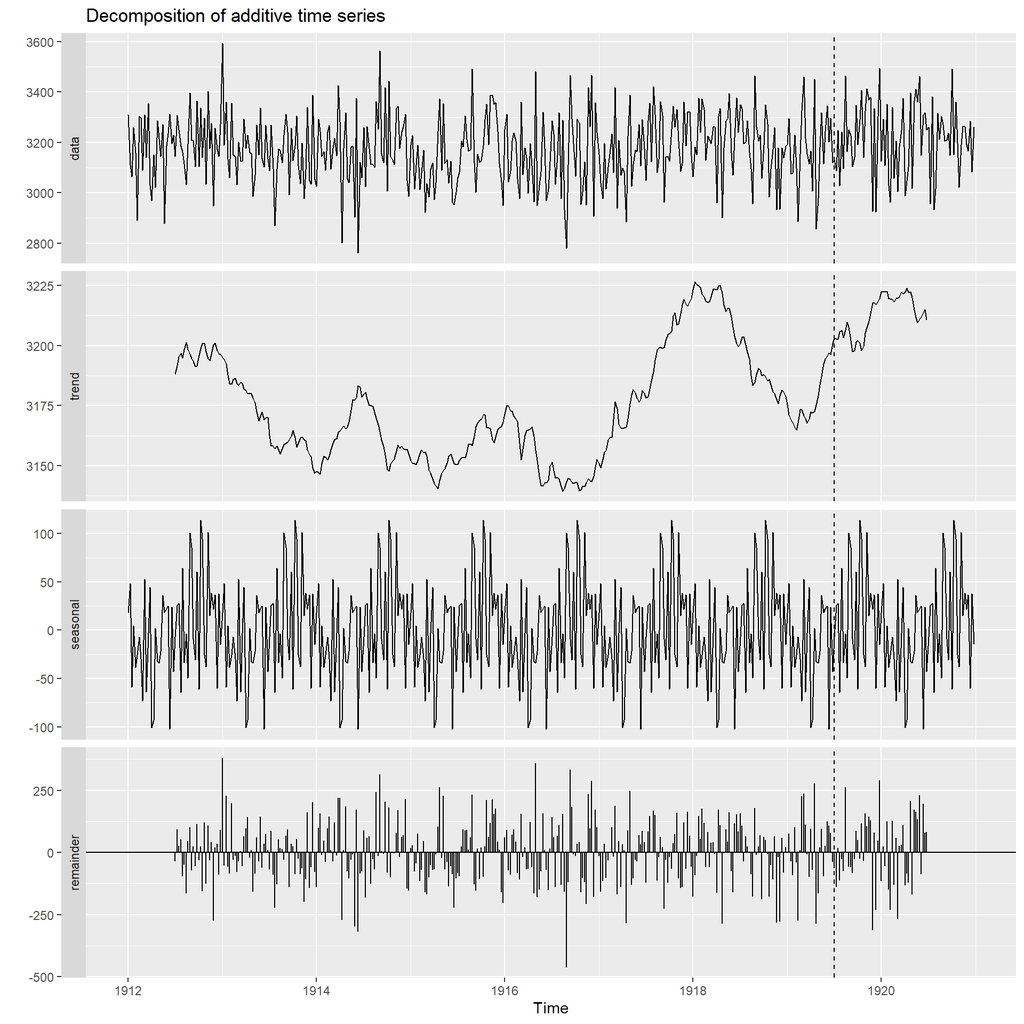

Monthly

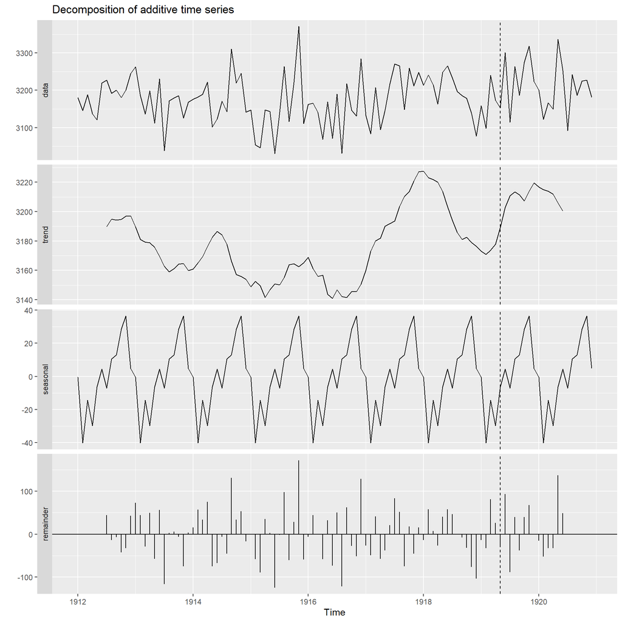

## 1.2 unadjusted

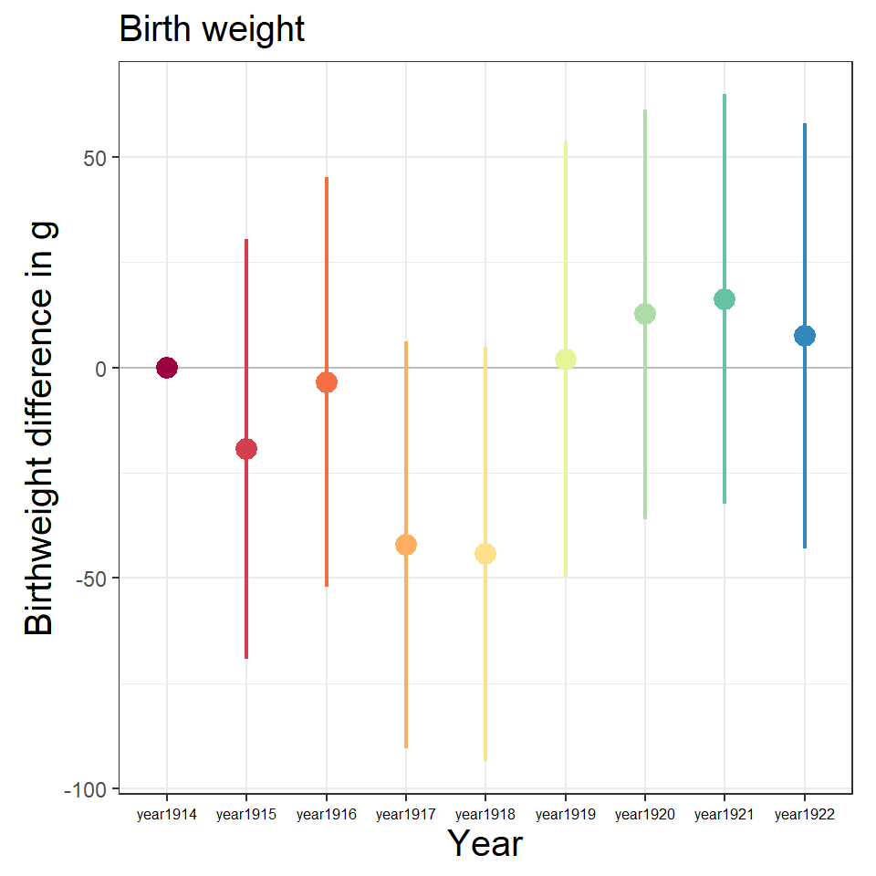

Quantile regression

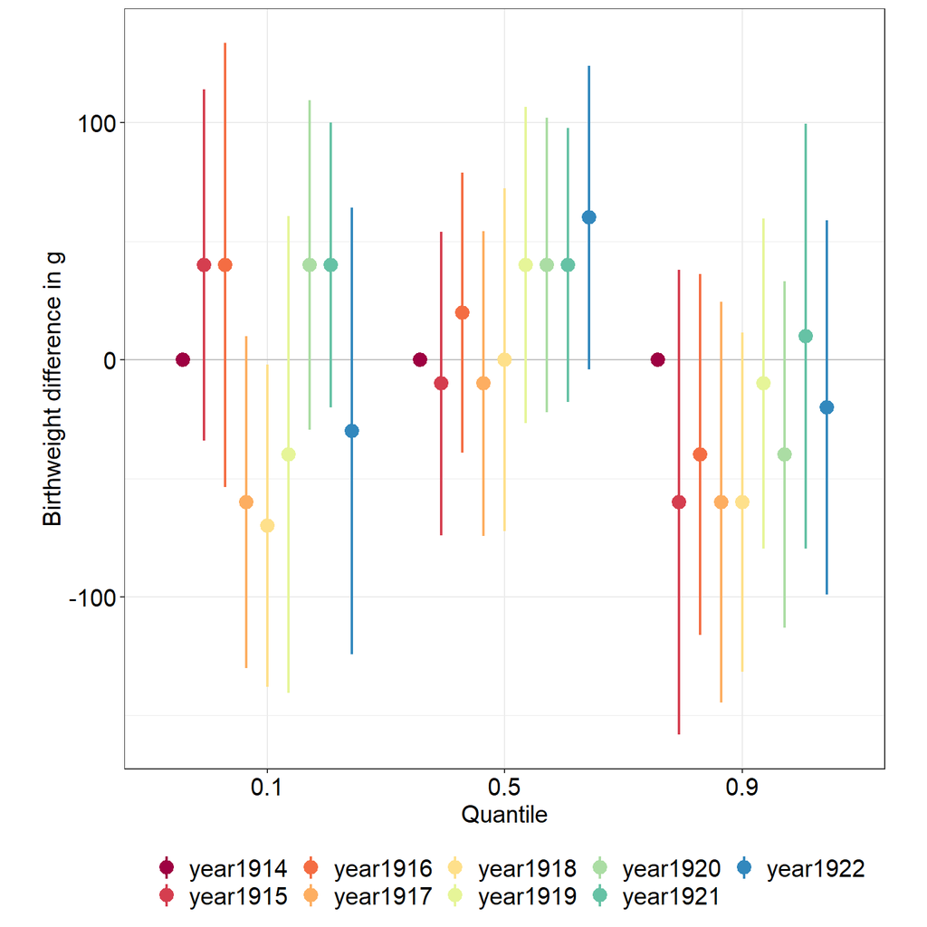

Lineare regression only Exposure

```
##
## Call:
## lm(formula = weight ~ Exposure_sum, data = datared)
##
## Residuals:
##      Min       1Q   Median       3Q      Max
## -1677.32  -307.32     2.68   304.75  2082.68
##
## Coefficients:
##               Estimate Std. Error t value Pr(>|t|)
## (Intercept)   3177.315      6.602 481.251   <2e-16 ***
## Exposure_sum1   25.209     24.776   1.017    0.309
## Exposure_sum2   29.108     26.490   1.099    0.272
## Exposure_sum3   -2.060     24.237  -0.085    0.932
## ---
## Signif. codes:  0 '***' 0.001 '**' 0.01 '*' 0.05 '.' 0.1 ' ' 1
##
## Residual standard error: 484.7 on 6587 degrees of freedom
## Multiple R-squared:  0.0003269,  Adjusted R-squared:  -0.0001284
## F-statistic: 0.7181 on 3 and 6587 DF,  p-value: 0.5411
```

Lineare regression only flu intensity

```
##
## Call:
## lm(formula = weight ~ Flu_intensity_all, data = datared)
##
## Residuals:
##      Min       1Q   Median       3Q      Max
## -1679.76  -309.76     0.24   310.24  2080.24
##
## Coefficients:
##                   Estimate Std. Error t value Pr(>|t|)
## (Intercept)       3179.762      6.285 505.917   <2e-16 ***
## Flu_intensity_all    9.639     33.166   0.291    0.771
## ---
## Signif. codes:  0 '***' 0.001 '**' 0.01 '*' 0.05 '.' 0.1 ' ' 1
##
## Residual standard error: 484.7 on 6589 degrees of freedom
## Multiple R-squared:  1.282e-05,  Adjusted R-squared:  -0.0001389
## F-statistic: 0.08446 on 1 and 6589 DF,  p-value: 0.7713
```

GAM regression

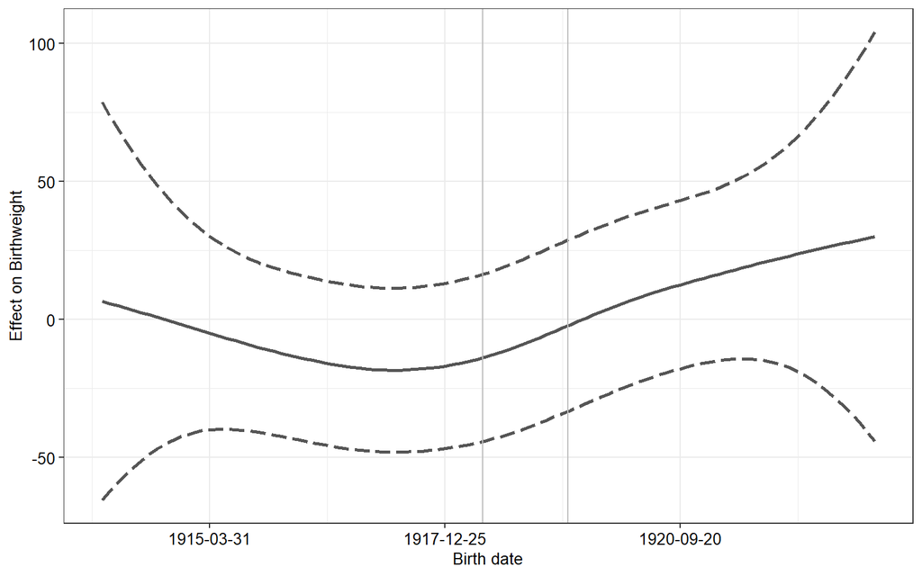

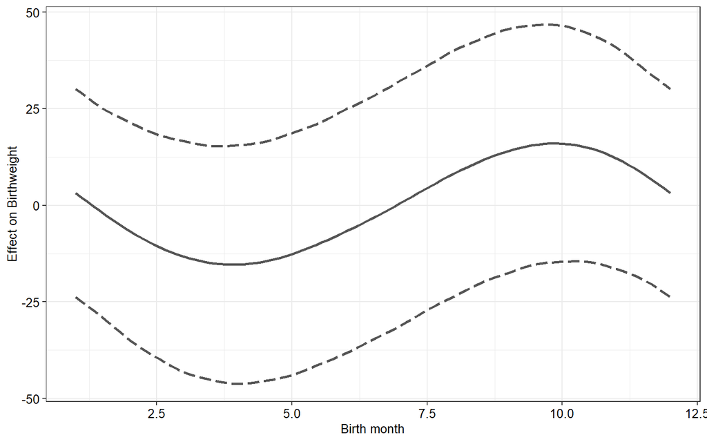

GAM regression and Exposure

```
##
## Family: gaussian
## Link function: identity
##
## Formula:
## weight ~ s(Birth_year_week_num, k = 20) + s(birth_month, bs = "cc",
##     k = 12) + Exposure_sum
##
## Parametric coefficients:
##               Estimate Std. Error t value Pr(>|t|)
## (Intercept)   3175.576      6.855 463.277   <2e-16 ***
## Exposure_sum1   35.776     26.503   1.350    0.177
## Exposure_sum2   31.205     29.044   1.074    0.283
## Exposure_sum3   12.668     26.529   0.478    0.633
## ---
## Signif. codes:  0 '***' 0.001 '**' 0.01 '*' 0.05 '.' 0.1 ' ' 1
##
## Approximate significance of smooth terms:
##                          edf Ref.df     F p-value
## s(Birth_year_week_num) 2.316  2.893 3.090  0.0463 *
## s(birth_month)         1.525 10.000 0.386  0.0584 .
## ---
## Signif. codes:  0 '***' 0.001 '**' 0.01 '*' 0.05 '.' 0.1 ' ' 1
##
## R-sq.(adj) =  0.00169   Deviance explained = 0.272%
## GCV = 2.348e+05  Scale est. = 2.3452e+05  n = 6591
```

GAM regression and flu intensity

```
##
## Family: gaussian
## Link function: identity
##
## Formula:
## weight ~ s(Birth_year_week_num, k = 20) + s(birth_month, bs = "cc",
##     k = 12) + Flu_intensity_all
##
## Parametric coefficients:
##                   Estimate Std. Error t value Pr(>|t|)
## (Intercept)       3178.839      6.344 501.117   <2e-16 ***
## Flu_intensity_all   25.225     36.456   0.692    0.489
## ---
## Signif. codes:  0 '***' 0.001 '**' 0.01 '*' 0.05 '.' 0.1 ' ' 1
##
## Approximate significance of smooth terms:
##                          edf Ref.df     F p-value
## s(Birth_year_week_num) 2.458   3.07 2.482  0.0615 .
## s(birth_month)         1.673  10.00 0.514  0.0291 *
## ---
## Signif. codes:  0 '***' 0.001 '**' 0.01 '*' 0.05 '.' 0.1 ' ' 1
##
## R-sq.(adj) =  0.00171   Deviance explained = 0.249%
## GCV = 2.3473e+05  Scale est. = 2.3451e+05  n = 6591
```

## 1.3 adjusted

Lineare regression

Exposure sum

```
##
## Call:
## lm(formula = weight ~ year + boy + parity + Gest_group + birth_month +
##     matage + married + city + Exposure_sum, data = datared)
##
## Residuals:
##     Min      1Q  Median      3Q     Max
## -1697.6  -293.6    -1.3   286.0  2043.2
##
## Coefficients:
##                  Estimate Std. Error t value Pr(>|t|)
## (Intercept)     3236.8471    39.1045  82.774  < 2e-16 ***
## year1915         -18.3448    23.7818  -0.771  0.44051
## year1916          -7.8208    23.1840  -0.337  0.73587
## year1917         -28.5563    23.0355  -1.240  0.21514
## year1918         -36.3393    27.0783  -1.342  0.17964
## year1919         -65.1034    49.9182  -1.304  0.19221
## year1920          15.6923    24.3184   0.645  0.51876
## year1921          19.4480    23.2592   0.836  0.40311
## year1922          17.8754    24.1423   0.740  0.45907
## boy0            -144.5381    11.1597 -12.952  < 2e-16 ***
## parity2          127.1140    15.3900   8.260  < 2e-16 ***
## parity3          177.4480    19.3705   9.161  < 2e-16 ***
## parity>=4        220.7744    17.9942  12.269  < 2e-16 ***
## Gest_groupearly -352.6864    15.8263 -22.285  < 2e-16 ***
## birth_month2     -41.4977    27.3916  -1.515  0.12983
## birth_month3      -5.8127    26.5279  -0.219  0.82657
## birth_month4      -6.6303    27.3066  -0.243  0.80816
## birth_month5     -15.0550    26.9941  -0.558  0.57706
## birth_month6      -2.6346    27.5212  -0.096  0.92374
## birth_month7     -14.6409    26.9580  -0.543  0.58708
## birth_month8       5.8263    27.6239   0.211  0.83296
## birth_month9      -5.4313    27.2810  -0.199  0.84220
## birth_month10     19.6903    27.4945   0.716  0.47392
## birth_month11     54.6633    28.2296   1.936  0.05286 .
## birth_month12     -9.2414    28.1764  -0.328  0.74294
## matage            -0.8958     1.1077  -0.809  0.41872
## married0         -40.7410    13.9840  -2.913  0.00359 **
## city0             13.2591    11.2723   1.176  0.23953
## Exposure_sum1     16.0070    27.5224   0.582  0.56086
## Exposure_sum2     44.4574    40.2522   1.104  0.26943
## Exposure_sum3     60.9833    50.5635   1.206  0.22783
## ---
## Signif. codes:  0 '***' 0.001 '**' 0.01 '*' 0.05 '.' 0.1 ' ' 1
##
## Residual standard error: 451.2 on 6543 degrees of freedom
##   (17 Beobachtungen als fehlend gelöscht)
## Multiple R-squared:  0.1374, Adjusted R-squared:  0.1334
## F-statistic: 34.74 on 30 and 6543 DF,  p-value: < 2.2e-16
```

Flu Intensity

```
##
## Call:
## lm(formula = weight ~ year + boy + parity + Gest_group + birth_month +
##     matage + married + city + Flu_intensity_all, data = datared)
##
## Residuals:
##      Min       1Q   Median       3Q      Max
## -1699.82  -293.50    -1.77   286.84  2045.48
##
## Coefficients:
##                    Estimate Std. Error t value Pr(>|t|)
## (Intercept)       3236.2128    39.0565  82.860  < 2e-16 ***
## year1915           -18.1594    23.7776  -0.764  0.44506
## year1916            -7.6462    23.1806  -0.330  0.74152
## year1917           -28.3619    23.0318  -1.231  0.21821
## year1918           -25.3496    24.2127  -1.047  0.29516
## year1919           -27.4526    34.9649  -0.785  0.43240
## year1920            20.4712    23.2122   0.882  0.37785
## year1921            19.6338    23.2548   0.844  0.39854
## year1922            18.0022    24.1374   0.746  0.45580
## boy0              -144.6452    11.1600 -12.961  < 2e-16 ***
## parity2            127.0742    15.3865   8.259  < 2e-16 ***
## parity3            176.5686    19.3512   9.124  < 2e-16 ***
## parity>=4          220.3382    17.9888  12.249  < 2e-16 ***
## Gest_groupearly   -352.6389    15.8093 -22.306  < 2e-16 ***
## birth_month2       -40.9405    27.3627  -1.496  0.13465
## birth_month3        -5.8970    26.5238  -0.222  0.82407
## birth_month4        -8.7025    27.1734  -0.320  0.74878
## birth_month5       -16.5913    26.8551  -0.618  0.53672
## birth_month6        -3.3119    27.4845  -0.121  0.90409
## birth_month7       -14.6636    26.9538  -0.544  0.58644
## birth_month8         6.3112    27.6137   0.229  0.81922
## birth_month9        -3.8269    27.2704  -0.140  0.88840
## birth_month10       21.9335    27.0761   0.810  0.41793
## birth_month11       56.8356    27.6663   2.054  0.03998 *
## birth_month12       -7.6872    27.8224  -0.276  0.78233
## matage              -0.8805     1.1076  -0.795  0.42666
## married0           -41.1194    13.9739  -2.943  0.00327 **
## city0               13.4533    11.2680   1.194  0.23254
## Flu_intensity_all   36.0391    51.1031   0.705  0.48070
## ---
## Signif. codes:  0 '***' 0.001 '**' 0.01 '*' 0.05 '.' 0.1 ' ' 1
##
## Residual standard error: 451.2 on 6545 degrees of freedom
##   (17 Beobachtungen als fehlend gelöscht)
## Multiple R-squared:  0.1372, Adjusted R-squared:  0.1335
## F-statistic: 37.18 on 28 and 6545 DF,  p-value: < 2.2e-16
```

GAM regression without gestational age

```
##
## Family: gaussian
## Link function: identity
##
## Formula:
## weight ~ s(Birth_year_week_num, k = 20) + s(birth_month, bs = "cc",
##     k = 12) + boy + parity + matage + married + city + Exposure_sum
##
## Parametric coefficients:
##                Estimate Std. Error t value Pr(>|t|)
## (Intercept)   3161.1941    31.8053  99.392  < 2e-16 ***
## boy0          -139.1855    11.5544 -12.046  < 2e-16 ***
## parity2        133.4068    15.9248   8.377  < 2e-16 ***
## parity3        187.2246    20.0386   9.343  < 2e-16 ***
## parity>=4      215.5988    18.6119  11.584  < 2e-16 ***
## matage          -0.4596     1.1464  -0.401 0.688507
## married0       -55.0852    14.4644  -3.808 0.000141 ***
## city0           17.6079    11.6767   1.508 0.131617
## Exposure_sum1   33.3093    25.9222   1.285 0.198848
## Exposure_sum2   29.7371    28.4737   1.044 0.296353
## Exposure_sum3   10.2460    26.0055   0.394 0.693599
## ---
## Signif. codes:  0 '***' 0.001 '**' 0.01 '*' 0.05 '.' 0.1 ' ' 1
##
## Approximate significance of smooth terms:
##                          edf Ref.df     F p-value
## s(Birth_year_week_num) 2.515   3.14 4.427 0.00414 **
## s(birth_month)         1.611  10.00 0.399 0.06100 .
## ---
## Signif. codes:  0 '***' 0.001 '**' 0.01 '*' 0.05 '.' 0.1 ' ' 1
##
## R-sq.(adj) =  0.0686   Deviance explained = 7.06%
## GCV = 2.193e+05  Scale est. = 2.188e+05  n = 6574
```

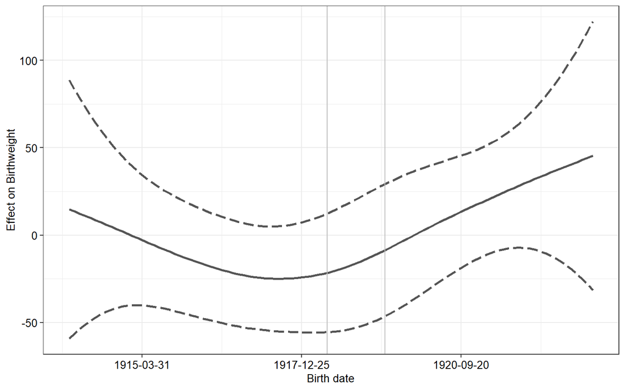

GAM regression with gestational age

```
##
## Family: gaussian
## Link function: identity
##
## Formula:
## weight ~ s(Birth_year_week_num, k = 20) + s(birth_month, bs = "cc",
##     k = 12) + boy + parity + Gest_group + matage + married +
##     city + Exposure_sum
##
## Parametric coefficients:
##                 Estimate Std. Error t value Pr(>|t|)
## (Intercept)     3231.008     30.815 104.852   <2e-16 ***
## boy0            -144.469     11.145 -12.963   <2e-16 ***
## parity2          126.785     15.363   8.253   <2e-16 ***
## parity3          175.872     19.331   9.098   <2e-16 ***
## parity>=4        220.157     17.955  12.262   <2e-16 ***
## Gest_groupearly -351.792     15.776 -22.300   <2e-16 ***
## matage            -0.900      1.106  -0.814   0.4157
## married0         -41.048     13.966  -2.939   0.0033 **
## city0             13.821     11.262   1.227   0.2198
## Exposure_sum1      6.151     24.600   0.250   0.8026
## Exposure_sum2      6.777     27.121   0.250   0.8027
## Exposure_sum3      1.418     24.256   0.058   0.9534
## ---
## Signif. codes:  0 '***' 0.001 '**' 0.01 '*' 0.05 '.' 0.1 ' ' 1
##
## Approximate significance of smooth terms:
##                          edf Ref.df     F p-value
## s(Birth_year_week_num) 2.000  2.501 3.255  0.0558 .
## s(birth_month)         3.482 10.000 0.605  0.1166
## ---
## Signif. codes:  0 '***' 0.001 '**' 0.01 '*' 0.05 '.' 0.1 ' ' 1
##
## R-sq.(adj) =  0.134   Deviance explained = 13.6%
## GCV = 2.0398e+05  Scale est. = 2.0344e+05  n = 6574
```

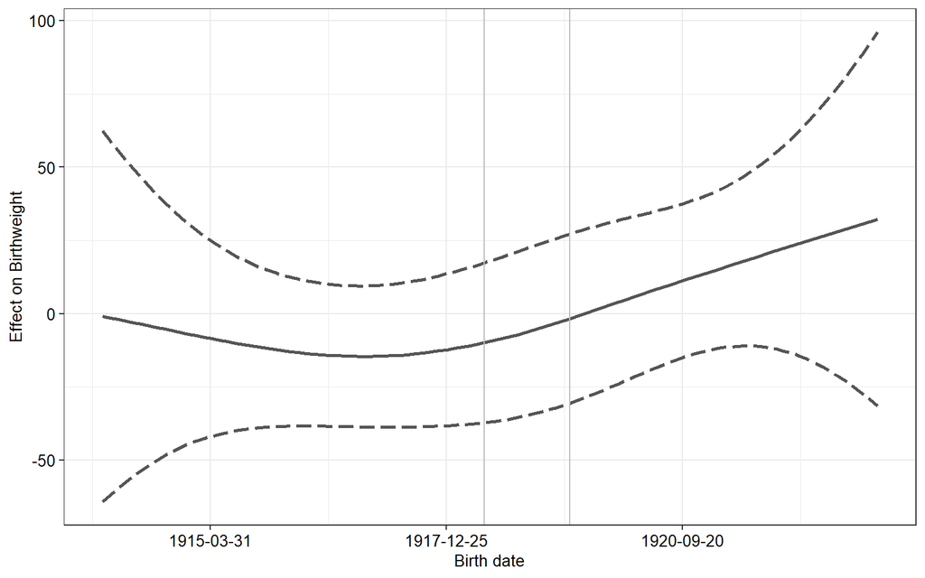

# 2 Gestational age

## 2.1 Table

| year | normal | early | total | perc_early |
| --- | --- | --- | --- | --- |
| 1914 | 647 | 105 | 752 | 13.96 |
| 1915 | 601 | 99 | 700 | 14.14 |
| 1916 | 662 | 113 | 775 | 14.58 |
| 1917 | 642 | 154 | 796 | 19.35 |
| 1918 | 611 | 131 | 742 | 17.65 |
| 1919 | 538 | 79 | 617 | 12.80 |
| 1920 | 675 | 98 | 773 | 12.68 |
| 1921 | 668 | 104 | 772 | 13.47 |
| 1922 | 572 | 92 | 664 | 13.86 |

## 2.2 Logistic Regression

I did the analysis with and without stillborns -> similar results. The results are shown with data without Stillborn. High multicollinearity between year and exposure sum and year and flu intensity. Therefor only one variable is used.

unadjusted

```
##
## Call:
## glm(formula = formula, family = binomial(link = "logit"), data = datared_still_n)
##
## Deviance Residuals:
##     Min       1Q   Median       3Q      Max
## -0.6558  -0.5614  -0.5462  -0.5207   2.0324
##
## Coefficients:
##              Estimate Std. Error z value Pr(>|z|)
## (Intercept) -1.818386   0.105211 -17.283  < 2e-16 ***
## year1915     0.014911   0.151110   0.099  0.92140
## year1916     0.050508   0.146388   0.345  0.73007
## year1917     0.390750   0.138277   2.826  0.00472 **
## year1918     0.278486   0.142617   1.953  0.05086 .
## year1919    -0.100025   0.159957  -0.625  0.53176
## year1920    -0.111359   0.150847  -0.738  0.46038
## year1921    -0.041511   0.148935  -0.279  0.78046
## year1922    -0.008964   0.153906  -0.058  0.95355
## ---
## Signif. codes:  0 '***' 0.001 '**' 0.01 '*' 0.05 '.' 0.1 ' ' 1
##
## (Dispersion parameter for binomial family taken to be 1)
##
##     Null deviance: 5524.6  on 6590  degrees of freedom
## Residual deviance: 5500.7  on 6582  degrees of freedom
## AIC: 5518.7
##
## Number of Fisher Scoring iterations: 4
```

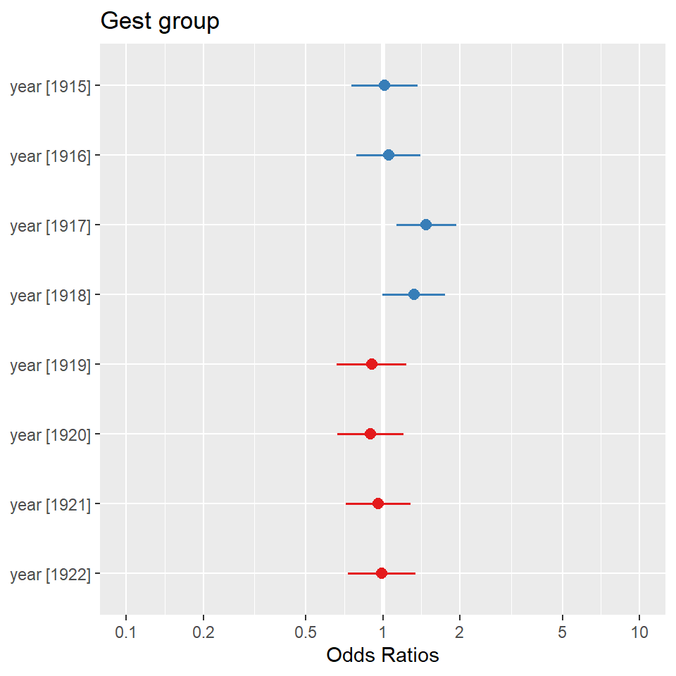

only exposure

```
##
## Call:
## glm(formula = formula, family = binomial(link = "logit"), data = datared_still_n)
##
## Deviance Residuals:
##     Min       1Q   Median       3Q      Max
## -0.5779  -0.5779  -0.5779  -0.5252   2.2079
##
## Coefficients:
##               Estimate Std. Error z value Pr(>|z|)
## (Intercept)   -1.70508    0.03776 -45.160  < 2e-16 ***
## Exposure_sum1 -0.64099    0.17845  -3.592 0.000328 ***
## Exposure_sum2 -0.20607    0.16242  -1.269 0.204519
## Exposure_sum3 -0.04412    0.14060  -0.314 0.753656
## ---
## Signif. codes:  0 '***' 0.001 '**' 0.01 '*' 0.05 '.' 0.1 ' ' 1
##
## (Dispersion parameter for binomial family taken to be 1)
##
##     Null deviance: 5524.6  on 6590  degrees of freedom
## Residual deviance: 5508.3  on 6587  degrees of freedom
## AIC: 5516.3
##
## Number of Fisher Scoring iterations: 4
```

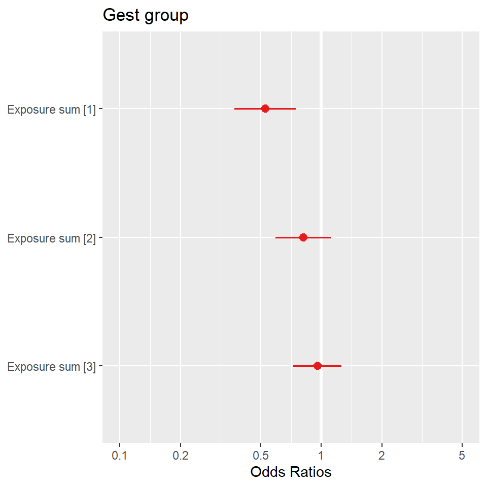

only flu intensity

```
##
## Call:
## glm(formula = formula, family = binomial(link = "logit"), data = datared_still_n)
##
## Deviance Residuals:
##     Min       1Q   Median       3Q      Max
## -0.5714  -0.5714  -0.5714  -0.5593   2.1082
##
## Coefficients:
##                   Estimate Std. Error z value Pr(>|z|)
## (Intercept)       -1.72976    0.03629 -47.662   <2e-16 ***
## Flu_intensity_all -0.38556    0.20913  -1.844   0.0652 .
## ---
## Signif. codes:  0 '***' 0.001 '**' 0.01 '*' 0.05 '.' 0.1 ' ' 1
##
## (Dispersion parameter for binomial family taken to be 1)
##
##     Null deviance: 5524.6  on 6590  degrees of freedom
## Residual deviance: 5521.0  on 6589  degrees of freedom
## AIC: 5525
##
## Number of Fisher Scoring iterations: 4
```

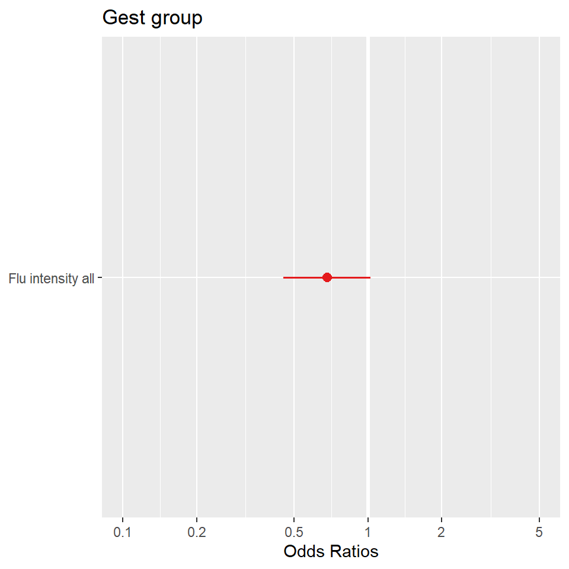

adjusted  
year

```
##
## Call:
## glm(formula = formula, family = binomial(link = "logit"), data = datared_still_n)
##
## Deviance Residuals:
##     Min       1Q   Median       3Q      Max
## -0.9057  -0.5979  -0.5268  -0.4577   2.3477
##
## Coefficients:
##                Estimate Std. Error z value Pr(>|z|)
## (Intercept)   -1.429987   0.245813  -5.817 5.98e-09 ***
## year1915       0.023781   0.152601   0.156 0.876162
## year1916       0.057092   0.148071   0.386 0.699812
## year1917       0.421173   0.139865   3.011 0.002602 **
## year1918       0.280107   0.144521   1.938 0.052602 .
## year1919      -0.102973   0.161429  -0.638 0.523547
## year1920      -0.103549   0.152397  -0.679 0.496841
## year1921      -0.052804   0.151282  -0.349 0.727056
## year1922       0.002613   0.155584   0.017 0.986601
## boy0          -0.120132   0.070411  -1.706 0.087982 .
## parity2       -0.144950   0.098821  -1.467 0.142434
## parity3       -0.261462   0.130473  -2.004 0.045074 *
## parity>=4      0.116647   0.113345   1.029 0.303416
## birth_month2  -0.304939   0.177045  -1.722 0.085000 .
## birth_month3  -0.020792   0.162427  -0.128 0.898144
## birth_month4   0.216032   0.160081   1.350 0.177169
## birth_month5  -0.120602   0.166653  -0.724 0.469267
## birth_month6   0.055257   0.165498   0.334 0.738467
## birth_month7  -0.076093   0.166735  -0.456 0.648123
## birth_month8  -0.227722   0.176077  -1.293 0.195903
## birth_month9  -0.420396   0.180432  -2.330 0.019809 *
## birth_month10 -0.341840   0.175552  -1.947 0.051507 .
## birth_month11  0.213582   0.162647   1.313 0.189126
## birth_month12 -0.181673   0.175209  -1.037 0.299785
## city0         -0.095032   0.071043  -1.338 0.181006
## matage        -0.009901   0.007105  -1.394 0.163438
## married0       0.311606   0.084545   3.686 0.000228 ***
## ---
## Signif. codes:  0 '***' 0.001 '**' 0.01 '*' 0.05 '.' 0.1 ' ' 1
##
## (Dispersion parameter for binomial family taken to be 1)
##
##     Null deviance: 5501.6  on 6573  degrees of freedom
## Residual deviance: 5407.9  on 6547  degrees of freedom
##   (17 Beobachtungen als fehlend gelöscht)
## AIC: 5461.9
##
## Number of Fisher Scoring iterations: 4
```

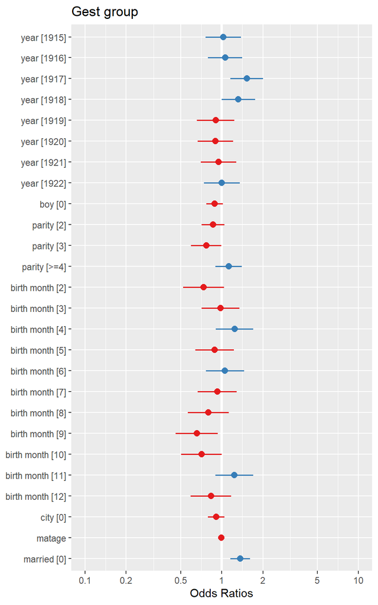

Exposure sum

```
##
## Call:
## glm(formula = formula, family = binomial(link = "logit"), data = datared_still_n)
##
## Deviance Residuals:
##     Min       1Q   Median       3Q      Max
## -0.7950  -0.6014  -0.5353  -0.4610   2.4661
##
## Coefficients:
##                Estimate Std. Error z value Pr(>|z|)
## (Intercept)   -1.301080   0.224263  -5.802 6.57e-09 ***
## boy0          -0.116433   0.070284  -1.657 0.097598 .
## parity2       -0.148517   0.098441  -1.509 0.131379
## parity3       -0.250573   0.130143  -1.925 0.054184 .
## parity>=4      0.116742   0.112775   1.035 0.300590
## birth_month2  -0.297282   0.177012  -1.679 0.093066 .
## birth_month3  -0.014146   0.162304  -0.087 0.930545
## birth_month4   0.183037   0.160074   1.143 0.252852
## birth_month5  -0.158823   0.166702  -0.953 0.340723
## birth_month6   0.049292   0.165280   0.298 0.765525
## birth_month7  -0.085007   0.166536  -0.510 0.609741
## birth_month8  -0.219388   0.175913  -1.247 0.212347
## birth_month9  -0.419793   0.180370  -2.327 0.019944 *
## birth_month10 -0.338638   0.177379  -1.909 0.056246 .
## birth_month11  0.194326   0.165787   1.172 0.241141
## birth_month12 -0.190049   0.176425  -1.077 0.281379
## city0         -0.089168   0.070970  -1.256 0.208966
## matage        -0.010097   0.007069  -1.428 0.153194
## married0       0.299948   0.084299   3.558 0.000373 ***
## Exposure_sum1 -0.580814   0.181353  -3.203 0.001362 **
## Exposure_sum2 -0.207941   0.174350  -1.193 0.233000
## Exposure_sum3 -0.051097   0.142443  -0.359 0.719807
## ---
## Signif. codes:  0 '***' 0.001 '**' 0.01 '*' 0.05 '.' 0.1 ' ' 1
##
## (Dispersion parameter for binomial family taken to be 1)
##
##     Null deviance: 5501.6  on 6573  degrees of freedom
## Residual deviance: 5420.5  on 6552  degrees of freedom
##   (17 Beobachtungen als fehlend gelöscht)
## AIC: 5464.5
##
## Number of Fisher Scoring iterations: 4
```

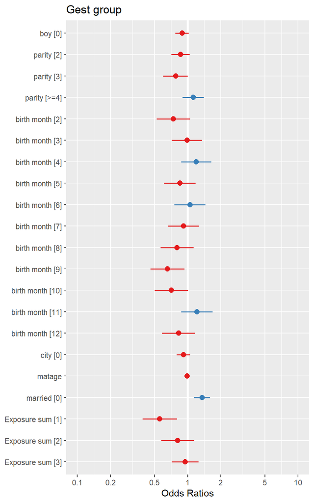

Flu_intensity_all

```
##
## Call:
## glm(formula = formula, family = binomial(link = "logit"), data = datared_still_n)
##
## Deviance Residuals:
##     Min       1Q   Median       3Q      Max
## -0.8033  -0.5981  -0.5343  -0.4695   2.2846
##
## Coefficients:
##                    Estimate Std. Error z value Pr(>|z|)
## (Intercept)       -1.333742   0.223707  -5.962 2.49e-09 ***
## boy0              -0.115028   0.070255  -1.637 0.101570
## parity2           -0.144926   0.098378  -1.473 0.140712
## parity3           -0.239022   0.130010  -1.838 0.065990 .
## parity>=4          0.124933   0.112737   1.108 0.267782
## birth_month2      -0.313572   0.176685  -1.775 0.075939 .
## birth_month3      -0.018141   0.162152  -0.112 0.910920
## birth_month4       0.231057   0.159712   1.447 0.147980
## birth_month5      -0.112791   0.166248  -0.678 0.497485
## birth_month6       0.068311   0.165054   0.414 0.678968
## birth_month7      -0.086514   0.166350  -0.520 0.603012
## birth_month8      -0.221114   0.175701  -1.258 0.208223
## birth_month9      -0.423614   0.180061  -2.353 0.018642 *
## birth_month10     -0.338228   0.175063  -1.932 0.053355 .
## birth_month11      0.196880   0.162152   1.214 0.224683
## birth_month12     -0.175335   0.174695  -1.004 0.315541
## city0             -0.095079   0.070903  -1.341 0.179930
## matage            -0.010161   0.007069  -1.437 0.150631
## married0           0.309795   0.084222   3.678 0.000235 ***
## Flu_intensity_all -0.414995   0.208437  -1.991 0.046482 *
## ---
## Signif. codes:  0 '***' 0.001 '**' 0.01 '*' 0.05 '.' 0.1 ' ' 1
##
## (Dispersion parameter for binomial family taken to be 1)
##
##     Null deviance: 5501.6  on 6573  degrees of freedom
## Residual deviance: 5429.2  on 6554  degrees of freedom
##   (17 Beobachtungen als fehlend gelöscht)
## AIC: 5469.2
##
## Number of Fisher Scoring iterations: 4
```

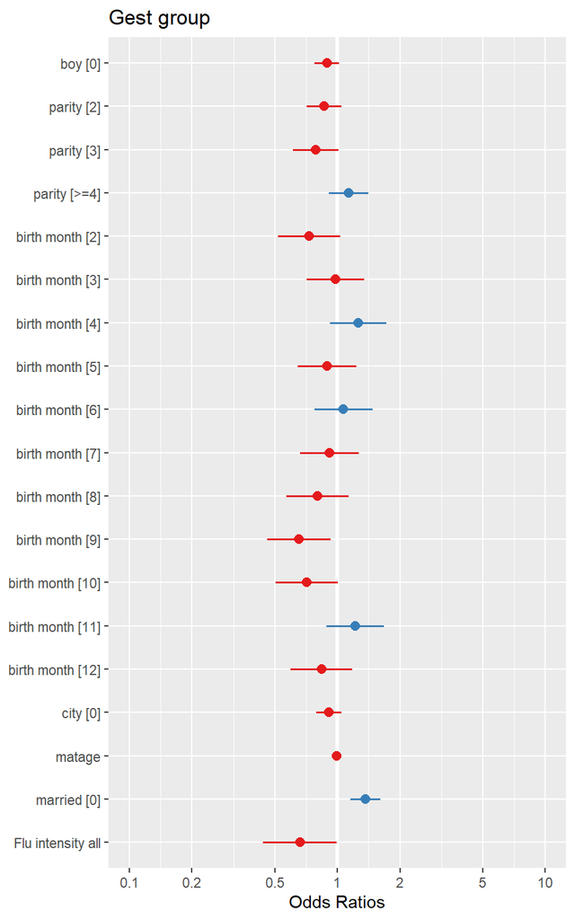

# 3 Stillborn

Data Bern

| year | alive | stillborn | perc_stillborn | alive_bfs | stillborn_bfs | perc_stillborn_bfs | Perc_diff |
| --- | --- | --- | --- | --- | --- | --- | --- |
| 1914 | 752 | 37 | 4.69 | 87330 | 2798 | 3.10 | -1.59 |
| 1915 | 700 | 26 | 3.58 | 75545 | 2386 | 3.06 | -0.52 |
| 1916 | 775 | 23 | 2.88 | 73660 | 2225 | 2.93 | 0.05 |
| 1917 | 796 | 28 | 3.40 | 72065 | 2060 | 2.78 | -0.62 |
| 1918 | 742 | 35 | 4.50 | 72658 | 2226 | 2.97 | -1.53 |
| 1919 | 617 | 39 | 5.95 | 72125 | 2080 | 2.80 | -3.15 |
| 1920 | 773 | 28 | 3.50 | 81190 | 2433 | 2.91 | -0.59 |
| 1921 | 772 | 35 | 4.34 | 80808 | 2365 | 2.84 | -1.50 |
| 1922 | 664 | 38 | 5.41 | 76290 | 2246 | 2.86 | -2.55 |

## 3.1 Logistic Regression

High multicollinearity between year and exposure sum and year and flu intensity. Therefor only one variable is used.

unadjusted

```
##
## Call:
## glm(formula = formula, family = binomial(link = "logit"), data = datared)
##
## Deviance Residuals:
##     Min       1Q   Median       3Q      Max
## -0.3501  -0.3099  -0.2978  -0.2630   2.6633
##
## Coefficients:
##             Estimate Std. Error z value Pr(>|z|)
## (Intercept) -3.01182    0.16839 -17.885   <2e-16 ***
## year1915    -0.28117    0.26124  -1.076   0.2818
## year1916    -0.50555    0.27042  -1.870   0.0615 .
## year1917    -0.33558    0.25559  -1.313   0.1892
## year1918    -0.04218    0.24140  -0.175   0.8613
## year1919     0.25051    0.23584   1.062   0.2881
## year1920    -0.30626    0.25567  -1.198   0.2310
## year1921    -0.08182    0.24130  -0.339   0.7346
## year1922     0.15112    0.23702   0.638   0.5237
## ---
## Signif. codes:  0 '***' 0.001 '**' 0.01 '*' 0.05 '.' 0.1 ' ' 1
##
## (Dispersion parameter for binomial family taken to be 1)
##
##     Null deviance: 2397.9  on 6879  degrees of freedom
## Residual deviance: 2383.4  on 6871  degrees of freedom
## AIC: 2401.4
##
## Number of Fisher Scoring iterations: 6
```

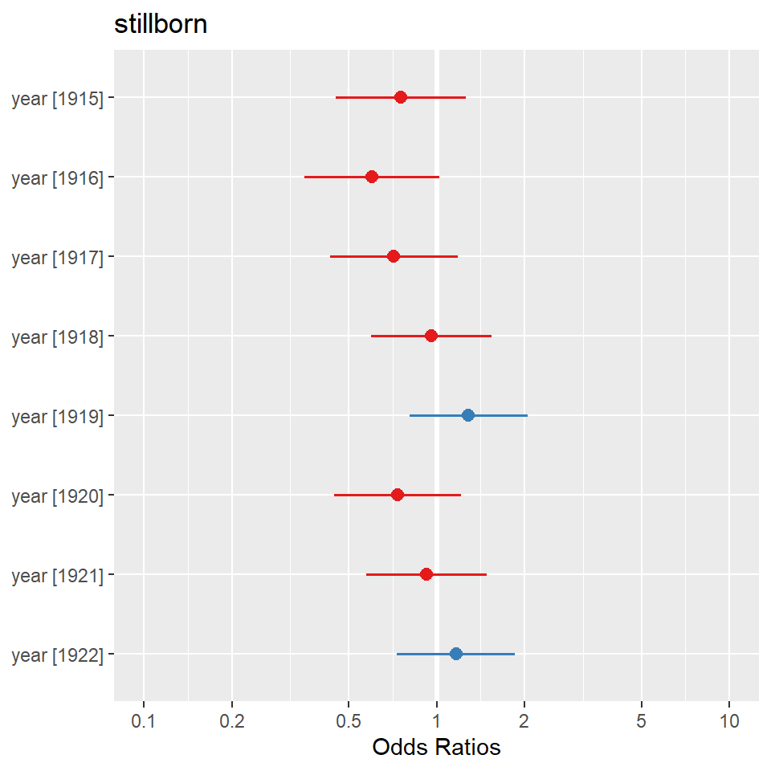

Only Exposure

```
##
## Call:
## glm(formula = formula, family = binomial(link = "logit"), data = datared)
##
## Deviance Residuals:
##     Min       1Q   Median       3Q      Max
## -0.3886  -0.2841  -0.2841  -0.2841   2.6701
##
## Coefficients:
##               Estimate Std. Error z value Pr(>|z|)
## (Intercept)   -3.18962    0.06848 -46.575  < 2e-16 ***
## Exposure_sum1 -0.34649    0.30075  -1.152  0.24928
## Exposure_sum2  0.64409    0.20786   3.099  0.00194 **
## Exposure_sum3  0.41703    0.20986   1.987  0.04690 *
## ---
## Signif. codes:  0 '***' 0.001 '**' 0.01 '*' 0.05 '.' 0.1 ' ' 1
##
## (Dispersion parameter for binomial family taken to be 1)
##
##     Null deviance: 2397.9  on 6879  degrees of freedom
## Residual deviance: 2384.5  on 6876  degrees of freedom
## AIC: 2392.5
##
## Number of Fisher Scoring iterations: 6
```

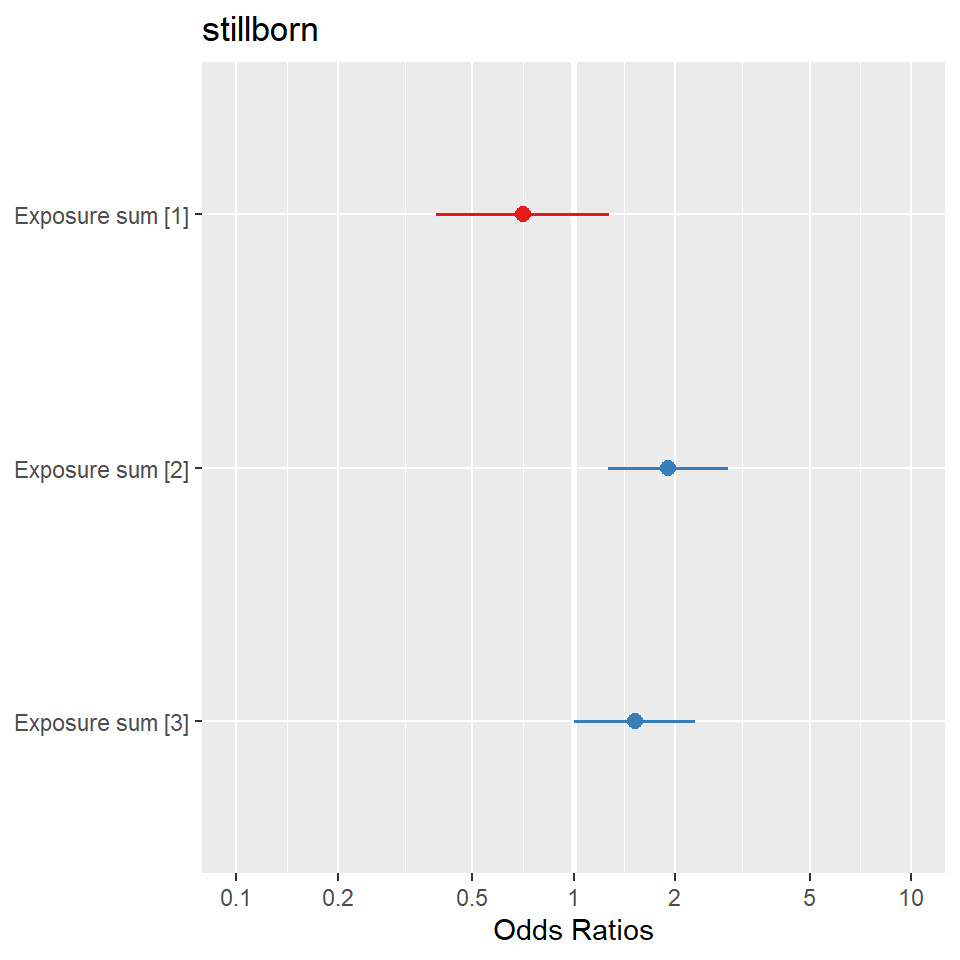

Only Flu Intensity

```
##
## Call:
## glm(formula = formula, family = binomial(link = "logit"), data = datared)
##
## Deviance Residuals:
##     Min       1Q   Median       3Q      Max
## -0.3959  -0.2860  -0.2860  -0.2860   2.5365
##
## Coefficients:
##                   Estimate Std. Error z value Pr(>|z|)
## (Intercept)        -3.1760     0.0646  -49.17   <2e-16 ***
## Flu_intensity_all   0.6826     0.2798    2.44   0.0147 *
## ---
## Signif. codes:  0 '***' 0.001 '**' 0.01 '*' 0.05 '.' 0.1 ' ' 1
##
## (Dispersion parameter for binomial family taken to be 1)
##
##     Null deviance: 2397.9  on 6879  degrees of freedom
## Residual deviance: 2392.6  on 6878  degrees of freedom
## AIC: 2396.6
##
## Number of Fisher Scoring iterations: 6
```

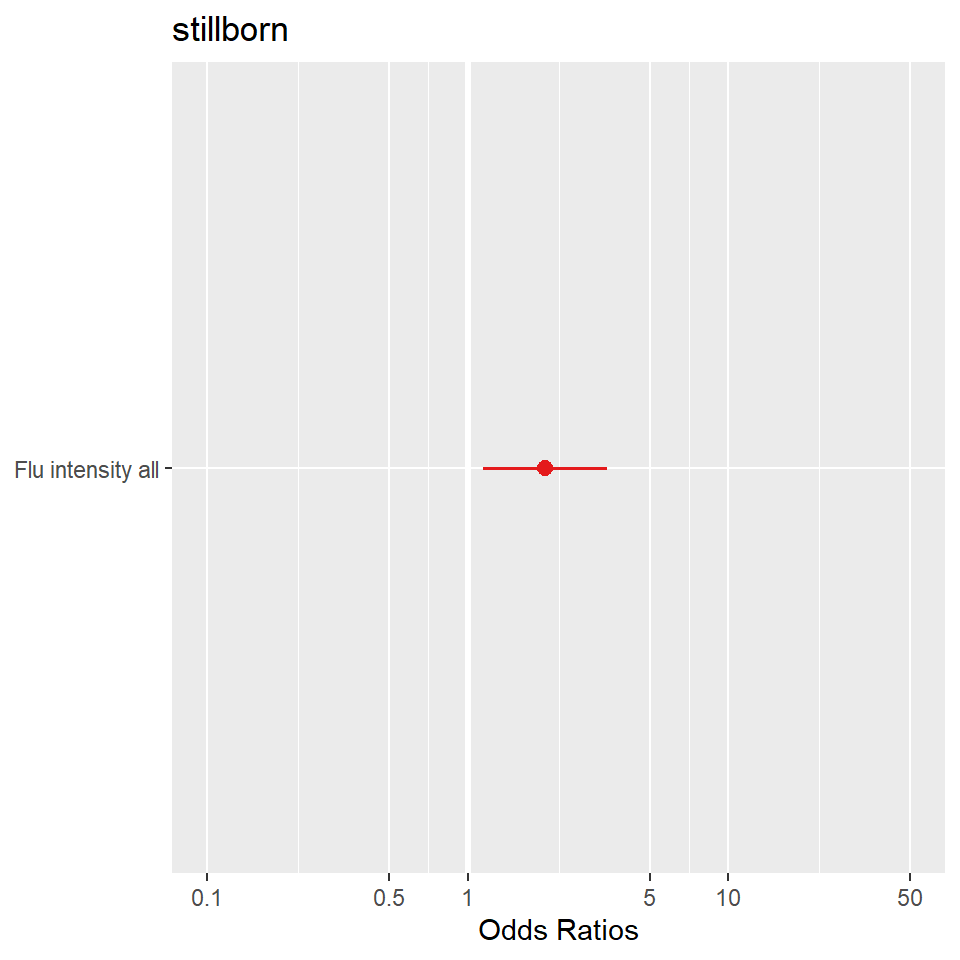

adjusted year

```
##
## Call:
## glm(formula = formula, family = binomial(link = "logit"), data = datared)
##
## Deviance Residuals:
##     Min       1Q   Median       3Q      Max
## -0.6956  -0.3146  -0.2520  -0.2111   3.0293
##
## Coefficients:
##             Estimate Std. Error z value Pr(>|z|)
## (Intercept) -5.29087    0.38450 -13.760  < 2e-16 ***
## year1915    -0.29981    0.26520  -1.131   0.2583
## year1916    -0.53025    0.27762  -1.910   0.0561 .
## year1917    -0.33239    0.25931  -1.282   0.1999
## year1918    -0.05811    0.24903  -0.233   0.8155
## year1919     0.24567    0.23997   1.024   0.3059
## year1920    -0.27254    0.25973  -1.049   0.2940
## year1921    -0.10241    0.24569  -0.417   0.6768
## year1922     0.13950    0.24297   0.574   0.5659
## boy0        -0.03338    0.12262  -0.272   0.7854
## parity2     -0.03583    0.18333  -0.195   0.8451
## parity3     -0.45698    0.25406  -1.799   0.0721 .
## parity>=4    0.19100    0.18058   1.058   0.2902
## birth_month  0.01390    0.01792   0.776   0.4378
## matage       0.06986    0.01091   6.403 1.52e-10 ***
## married0     0.08359    0.16450   0.508   0.6114
## city0        0.24764    0.12506   1.980   0.0477 *
## ---
## Signif. codes:  0 '***' 0.001 '**' 0.01 '*' 0.05 '.' 0.1 ' ' 1
##
## (Dispersion parameter for binomial family taken to be 1)
##
##     Null deviance: 2364.7  on 6857  degrees of freedom
## Residual deviance: 2260.9  on 6841  degrees of freedom
##   (22 Beobachtungen als fehlend gelöscht)
## AIC: 2294.9
##
## Number of Fisher Scoring iterations: 6
```

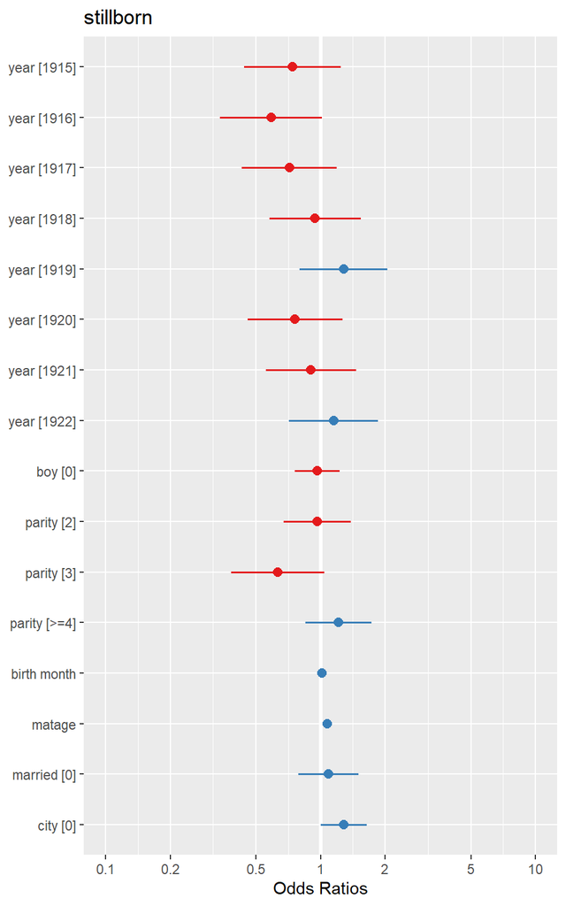

adjusted Exp

```
##
## Call:
## glm(formula = formula, family = binomial(link = "logit"), data = datared)
##
## Deviance Residuals:
##     Min       1Q   Median       3Q      Max
## -0.6957  -0.3157  -0.2499  -0.2122   2.9066
##
## Coefficients:
##                Estimate Std. Error z value Pr(>|z|)
## (Intercept)   -5.371042   0.350513 -15.323  < 2e-16 ***
## boy0          -0.038622   0.122600  -0.315  0.75275
## parity2       -0.063291   0.183261  -0.345  0.72982
## parity3       -0.477361   0.254067  -1.879  0.06026 .
## parity>=4      0.175582   0.180885   0.971  0.33170
## birth_month    0.002285   0.018984   0.120  0.90420
## matage         0.069419   0.010914   6.361 2.01e-10 ***
## married0       0.076881   0.164762   0.467  0.64077
## city0          0.255128   0.124963   2.042  0.04119 *
## Exposure_sum1 -0.420006   0.315959  -1.329  0.18375
## Exposure_sum2  0.618525   0.222674   2.778  0.00547 **
## Exposure_sum3  0.435533   0.213535   2.040  0.04139 *
## ---
## Signif. codes:  0 '***' 0.001 '**' 0.01 '*' 0.05 '.' 0.1 ' ' 1
##
## (Dispersion parameter for binomial family taken to be 1)
##
##     Null deviance: 2364.7  on 6857  degrees of freedom
## Residual deviance: 2261.8  on 6846  degrees of freedom
##   (22 Beobachtungen als fehlend gelöscht)
## AIC: 2285.8
##
## Number of Fisher Scoring iterations: 6
```

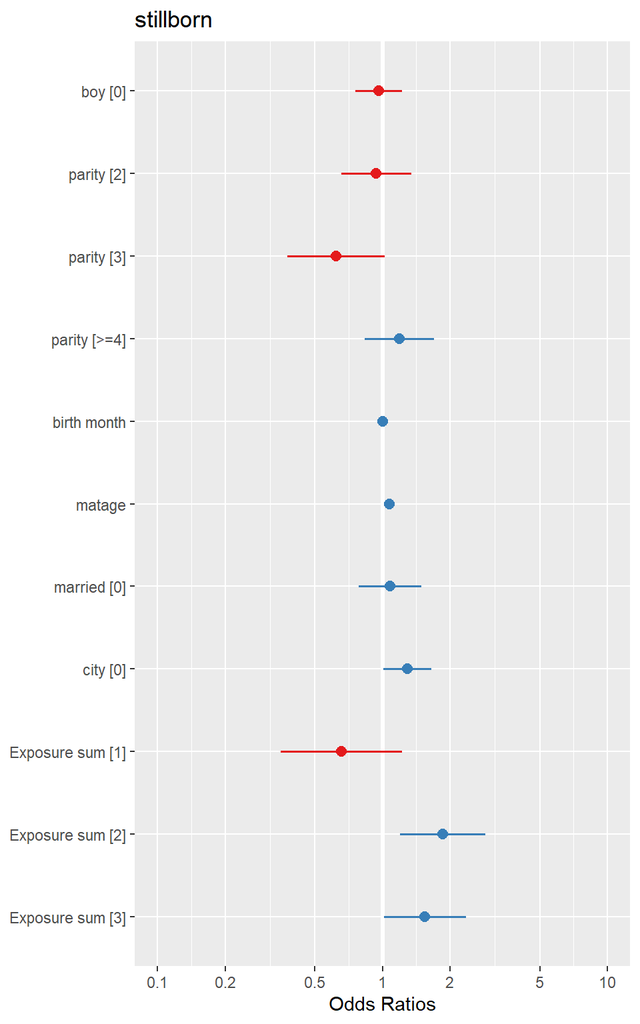

adjusted Int

```
##
## Call:
## glm(formula = formula, family = binomial(link = "logit"), data = datared)
##
## Deviance Residuals:
##     Min       1Q   Median       3Q      Max
## -0.7084  -0.3152  -0.2514  -0.2154   2.9119
##
## Coefficients:
##                   Estimate Std. Error z value Pr(>|z|)
## (Intercept)       -5.46307    0.34818 -15.690  < 2e-16 ***
## boy0              -0.03780    0.12249  -0.309   0.7577
## parity2           -0.04887    0.18300  -0.267   0.7894
## parity3           -0.47769    0.25373  -1.883   0.0597 .
## parity>=4          0.17682    0.18054   0.979   0.3274
## birth_month        0.01731    0.01790   0.967   0.3337
## matage             0.06946    0.01090   6.371 1.87e-10 ***
## married0           0.07933    0.16452   0.482   0.6297
## city0              0.25338    0.12481   2.030   0.0423 *
## Flu_intensity_all  0.69001    0.28618   2.411   0.0159 *
## ---
## Signif. codes:  0 '***' 0.001 '**' 0.01 '*' 0.05 '.' 0.1 ' ' 1
##
## (Dispersion parameter for binomial family taken to be 1)
##
##     Null deviance: 2364.7  on 6857  degrees of freedom
## Residual deviance: 2269.6  on 6848  degrees of freedom
##   (22 Beobachtungen als fehlend gelöscht)
## AIC: 2289.6
##
## Number of Fisher Scoring iterations: 6
```

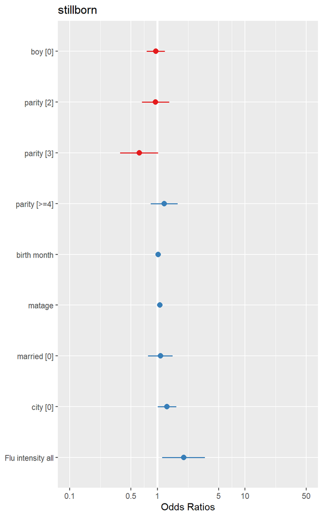